# Titanic Dataset Visualization -Group 10

[figure not shown]

I am one of the Kagglers who **love** visualization.

For those of you who are tired of the excessive Titanic Dataset, I will create a higher quality visualization.

I particularly pay attention to **color** and **placement**. Also, I am studying how to proceed with visualization without misunderstanding of interpretation.

> **Goal** : Let's create *The Economist*-style visualization material with only python basic library **matplotlib & seaborn**

**Have fun and if you liked it, please upvote!**

- **Timeline visualization** : Matplotlib Techniques
- **Ridgeplot** : Effective Multi Distribution
- **Barplot** : How to Customize Bar?
- **Stripplot** : Effective distribution plot
- **Heatmap** : How t Custom Heatmap?
- **Dimension Reduction + Scatter** ### Implement Python Basic Library Matplotlib & Seaborn & Pandas & Numpy.

```python
import matplotlib as mpl
import matplotlib.pyplot as plt
import matplotlib.gridspec as grid_spec
from matplotlib.ticker import FuncFormatter

import seaborn as sns

import numpy as np
import pandas as pd
```

```python
data = pd.read_csv(r"C:\Users\rites\OneDrive\Desktop\gender_submission.csv")
data.shape
```

```
(418, 2)
```

```python
data.size
print("Dataset shape:", data.shape)
print("Column names:", data.columns)
```

```
Dataset shape: (418, 2)
Column names: Index(['PassengerId', 'Survived'], dtype='object')
```

```python
data.head()
```

|  | PassengerId | Survived |
| --- | --- | --- |
| 0 | 892 | 0 |
| 1 | 893 | 1 |
| 2 | 894 | 0 |
| 3 | 895 | 0 |
| 4 | 896 | 1 |

```python
data
```

|  | PassengerId | Survived |
| --- | --- | --- |
| 0 | 892 | 0 |
| 1 | 893 | 1 |
| 2 | 894 | 0 |
| 3 | 895 | 0 |
| 4 | 896 | 1 |
| ... | ... | ... |
| 413 | 1305 | 0 |
| 414 | 1306 | 1 |
| 415 | 1307 | 0 |
| 416 | 1308 | 0 |
| 417 | 1309 | 0 |

418 rows × 2 columns

# Awesome Timeline Visualization

- A **Timeline** is a graphical way of displaying a list of events in chronological order.
- line + scatter + **stem plot**

### Simple Explanation

```python
sns.palplot(['#0000ff', '#008000', '#fafafa'])
```

[output not shown]

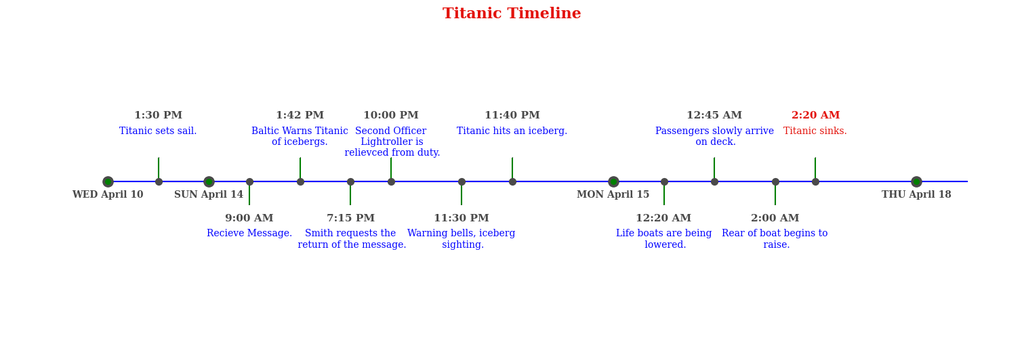

```python
from datetime import datetime


tl_dates = [
    "WED April 10",
    "SUN April 14",
    "MON April 15",
    "THU April 18"
]

tl_x = [1, 2, 6, 9]

tl_sub_x = [1.5, 2.4, 2.9, 3.4, 3.8, 4.5, 5.0, 6.5, 7, 7.6, 8]
tl_sub_times = [
    "1:30 PM",
    "9:00 AM",
    "1:42 PM",
    "7:15 PM",
    "10:00 PM",
    "11:30 PM",
    "11:40 PM",
    "12:20 AM",
    "12:45 AM",
    "2:00 AM",
    "2:20 AM",
]

tl_text = [
    "Titanic sets sail.",
    "Recieve Message.",
    "Baltic Warns Titanic\nof icebergs.",
    "Smith requests the\n return of the message.",
    "Second Officer\n Lightroller is\n relievced from duty.",
    "Warning bells, iceberg\n sighting.",
    "Titanic hits an iceberg.",
    "Life boats are being\n lowered.",
    "Passengers slowly arrive\n on deck.",
    "Rear of boat begins to\n raise.",
    "Titanic sinks."
]

# Set figure & Axes
fig, ax = plt.subplots(figsize=(15, 5), constrained_layout=True)
ax.set_ylim(-2, 2)
ax.set_xlim(0, 10)


# Timeline : line
ax.axhline(0, xmin=0.1, xmax=0.95, c='#0000ff', zorder=1)
# Timeline : Date Points
ax.scatter(tl_x, np.zeros(len(tl_x)), s=120, c='#4a4a4a', zorder=2)
ax.scatter(tl_x, np.zeros(len(tl_x)), s=30, c='#008000', zorder=3)
# Timeline : Time Points
ax.scatter(tl_sub_x, np.zeros(len(tl_sub_x)), s=50, c='#4a4a4a',zorder=4)

# Date Text
for x, date in zip(tl_x, tl_dates):
    ax.text(x, -0.2, date, ha='center',
            fontfamily='serif', fontweight='bold',
            color='#4a4a4a')


# Stemplot : vertical line
levels = np.zeros(len(tl_sub_x))
levels[::2] = 0.3
levels[1::2] = -0.3
markerline, stemline, baseline = ax.stem(tl_sub_x, levels, use_line_collection=True)
plt.setp(baseline, zorder=0)
plt.setp(markerline, marker=',', color='#4a4a4a')
plt.setp(stemline, color='#008000')

# Text
for idx, x, time, txt in zip(range(1, len(tl_sub_x)+1), tl_sub_x, tl_sub_times, tl_text):
    ax.text(x, 1.3*(idx%2)-0.5, time, ha='center',
            fontfamily='serif', fontweight='bold',
            color='#4a4a4a' if idx!=len(tl_sub_x) else '#e3120b', fontsize=11)

    ax.text(x, 1.3*(idx%2)-0.6, txt, va='top', ha='center',
        fontfamily='serif',color='#0000ff' if idx!=len(tl_sub_x) else '#e3120b')

# Spine
for spine in ["left", "top", "right", "bottom"]:
    ax.spines[spine].set_visible(False)

# Ticks
ax.set_xticks([])
ax.set_yticks([])

# Title
ax.set_title("Titanic Timeline", fontweight="bold", fontfamily='serif', fontsize=16, color='#e3120b')

plt.show()
```

# Awesome Distribution Visualization (Ridgeplot)

### Simple Explanation

- **Step1** : Use Gridspec
- **Step2** : Create density plot using seaborn's kdeplot
  - `bw` : bandwidth
  - `edgecolor` : to separate each density plot
  - `alpha` : remove transparency
  - `cut` : clear meaning
- **Step3** : Remove ticks & labels except last xticks
- **Step4** : Remove Spine
- **Step5** : Make plots closer & Make the background transparent
- **Step6** : add subtext (figure title, axes title)

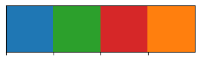

```python
sns.palplot(["#1f77b4", "#2ca02c", "#d62728", "#ff7f0e"])
```

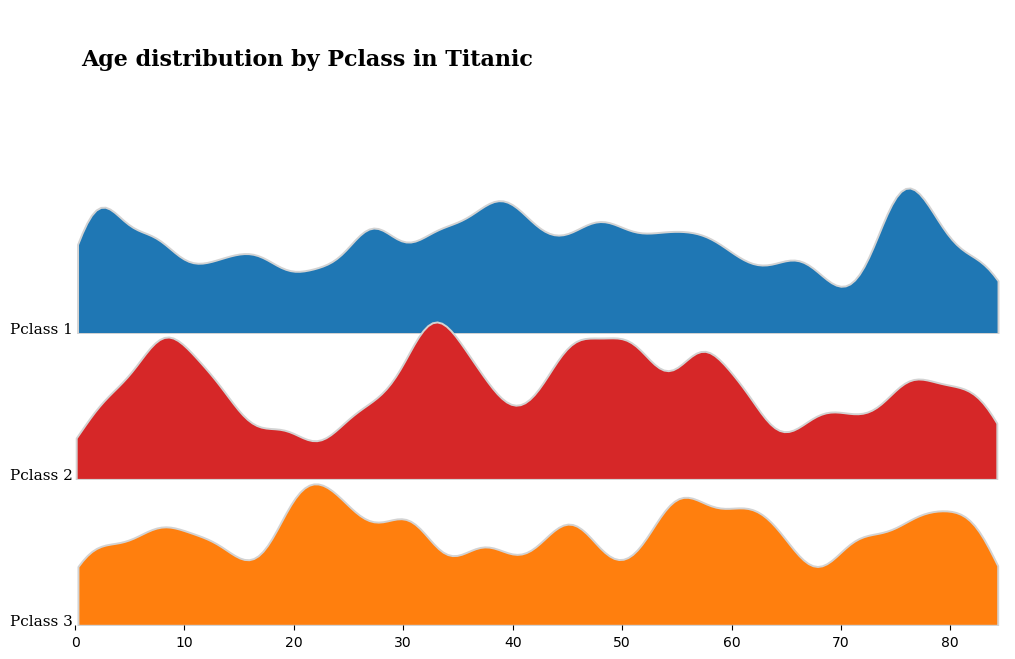

```python
# sample DataFrame
np.random.seed(0)
data = pd.DataFrame({
    'Pclass': np.random.choice([1, 2, 3], size=500),
    'Age': np.random.uniform(0, 85, size=500)
})

# Ensure the 'Pclass' column exists
if 'Pclass' not in data.columns or 'Age' not in data.columns:
    raise ValueError("DataFrame must contain 'Pclass' and 'Age' columns")

# figure and subplots
fig = plt.figure(figsize=(12, 8))
gs = fig.add_gridspec(3, 1)
gs.update(hspace=-0.55)

axes = []
colors = ["#1f77b4", "#d62728", "#ff7f0e"]
for idx, cls in enumerate(sorted(data['Pclass'].unique())):
    axes.append(fig.add_subplot(gs[idx, 0]))

    # Plot KDE for each class
    sns.kdeplot(x='Age', data=data[data['Pclass'] == cls],
                fill=True, ax=axes[idx], cut=0, bw_adjust=0.25,
                lw=1.4, edgecolor='lightgray', color=colors[idx], alpha=1)

    # Set limits and ticks
    axes[idx].set_ylim(0, 0.04)
    axes[idx].set_xlim(0, 85)
    axes[idx].set_yticks([])
    if idx != 2:
        axes[idx].set_xticks([])
    axes[idx].set_ylabel('')
    axes[idx].set_xlabel('')

    # Hide spines
    for spine in ["top", "right", "left", "bottom"]:
        axes[idx].spines[spine].set_visible(False)

    axes[idx].patch.set_alpha(0)
    axes[idx].text(-0.2, 0, f'Pclass {cls}', fontweight="light", fontfamily='serif', fontsize=11, ha="right")

# Add a main title
fig.text(0.13, 0.81, "Age distribution by Pclass in Titanic", fontweight="bold", fontfamily='serif', fontsize=16)

plt.show()
```

```python
sns.color_palette(sns.color_palette("PuBu", 5))
```

[output not shown]

# Awesome Barplot Visualization

**library** : matplotlib, seaborn **colortheme** from [The Economist Colors](https://pattern-library.economist.com/color.html)

## Simple Explanation

Grid Color difference in the bar you want to emphasize Average line and text annotations for it Minimize the y-axis information and add it as an annotation to each bar

```python
sns.palplot(['#1f77b4', '#d62728', '#2ca02c'])
```

[output not shown]

[figure not shown]

```python
np.random.seed(0)
data = pd.DataFrame({
    'Age': np.random.uniform(0, 85, size=500),
    'Survived': np.random.choice([0, 1], size=500)
})
# Define the age band function
def age_band(num):
    for i in range(1, 100):
        if num < 10 * i:
            return f'{(i - 1) * 10} ~ {i * 10}'

# Apply the age band function
data['age_band'] = data['Age'].apply(age_band)
# Calculate survival rates
titanic_age = data[['age_band', 'Survived']].groupby('age_band')['Survived'].value_counts().sort_index().unstack().fillna(0)
titanic_age['Survival rate'] = titanic_age[1] / (titanic_age[0] + titanic_age[1]) * 100

# Plotting
fig, ax = plt.subplots(1, 1, figsize=(10, 7))
# Update color_map to use previous colors
color_map = ['#1f77b4' for _ in range(len(titanic_age))]  # Blue
color_map[0] = color_map[-1] = '#d62728'

ax.bar(titanic_age['Survival rate'].index, titanic_age['Survival rate'],
       color=color_map, width=0.55,
       edgecolor='black',
       linewidth=0.7)
# Remove spines
for s in ["top", "right", "left"]:
    ax.spines[s].set_visible(False)

# Annotation Part
for i in titanic_age['Survival rate'].index:
    ax.annotate(f"{titanic_age['Survival rate'][i]:.02f}%",
                xy=(i, titanic_age['Survival rate'][i] + 2.3),
                va='center', ha='center', fontweight='light',
                color='#4a4a4a')

# Mean line and annotation
mean = data['Survived'].mean() * 100
ax.axhline(mean, color='black', linewidth=0.4, linestyle='dashdot')
ax.annotate(f"Mean: {mean:.2f}%",
            xy=('70 ~ 80', mean + 4),
            va='center', ha='center',
            color='#4a4a4a',
            bbox=dict(boxstyle='round', pad=0.4, facecolor='#efe8d1', linewidth=0))

# Title & Subtitle
fig.text(0.06, 1, 'Age Band & Survival Rate', fontsize=15, fontweight='bold', fontfamily='serif')
fig.text(0.06, 0.96, 'It can be seen that the survival rate of young children and the elderly is high.', fontsize=12, fontweight='light', fontfamily='serif')

# Y-axis ticks and grid
grid_y_ticks = np.arange(0, 101, 20)
ax.set_yticks(grid_y_ticks)
ax.grid(axis='y', linestyle='-', alpha=0.4)

plt.tight_layout()
plt.show()
```